# Rule Resource Usage and Default Tuning

## Per-rule usage vs. configured resources

Peak observed usage vs. currently configured resources, sorted by memory pressure

| rule | is_custom | n | peak_mem_mb | cfg_mem_mb | mem_pct_of_cfg | peak_wall_min | cfg_time_min | time_pct_of_cfg | cfg_cpus | peak_load_pct |
| --- | --- | --- | --- | --- | --- | --- | --- | --- | --- | --- |
| maf_split_chr_by_group | TRUE | 2 | 3227.2 | 8000 | 40.3 | 1.4 | 180 | 0.8 | 1 | 87.2 |
| picard_scatter_by_ns | TRUE | 1 | 2843.2 | 8000 | 35.5 | 1.6 | 180 | 0.9 | 1 | 70.4 |
| cnee_alignments_chr | TRUE | 21 | 1401.1 | 6000 | 23.4 | 1.5 | 120 | 1.3 | 4 | 259.5 |
| extract_4d_codons_by_chr | TRUE | 21 | 1686.8 | 8000 | 21.1 | 56.6 | 180 | 31.5 | 1 | 99.3 |
| maf_split_chunks | TRUE | 21 | 766.2 | 6000 | 12.8 | 16.0 | 120 | 13.3 | 1 | 86.7 |
| run_phastcons_chr | FALSE | 21 | 222.2 | 4000 | 5.6 | 120.7 | 60 | 201.2 | 1 | 2.3 |
| phastcons_concat_chr | FALSE | 21 | 197.4 | 4000 | 4.9 | 12.4 | 60 | 20.6 | 1 | 20.1 |
| summary_report | FALSE | 1 | 190.1 | 4000 | 4.8 | 0.6 | 60 | 1.1 | 1 | 4.4 |
| cnees_from_conserved_chr | FALSE | 21 | 167.6 | 4000 | 4.2 | 0.0 | 60 | 0.0 | 1 | 43.5 |
| get_gc_content | FALSE | 1 | 128.2 | 4000 | 3.2 | 0.2 | 60 | 0.4 | 1 | 5.5 |
| ref_gff_split_by_chr | FALSE | 21 | 110.6 | 4000 | 2.8 | 0.1 | 60 | 0.1 | 1 | 76.3 |
| ns_to_bed | FALSE | 21 | 106.0 | 4000 | 2.7 | 0.0 | 60 | 0.0 | 1 | 0.0 |
| extract_cds_bed_chr | FALSE | 21 | 104.7 | 4000 | 2.6 | 0.1 | 60 | 0.1 | 1 | 80.8 |
| run_mod_freqs | FALSE | 21 | 103.0 | 4000 | 2.6 | 0.0 | 60 | 0.0 | 1 | 0.0 |
| cnees_to_bed4_chr | FALSE | 21 | 102.8 | 4000 | 2.6 | 0.0 | 60 | 0.0 | 1 | 0.0 |
| extract_4d_sites | FALSE | 21 | 102.4 | 4000 | 2.6 | 0.0 | 60 | 0.0 | 1 | 0.0 |
| filter_4d_sites | FALSE | 21 | 102.3 | 4000 | 2.6 | 0.0 | 60 | 0.0 | 1 | 0.0 |
| make_group_beds | FALSE | 2 | 99.5 | 4000 | 2.5 | 0.0 | 60 | 0.0 | 1 | 0.0 |
| maf_index_chr | TRUE | 21 | 137.1 | 6000 | 2.3 | 0.8 | 120 | 0.7 | 1 | 95.3 |
| filter_maf_by_gap | TRUE | 21 | 115.1 | 6000 | 1.9 | 3.7 | 120 | 3.1 | 1 | 61.8 |
| run_phylofit | TRUE | 21 | 111.9 | 6000 | 1.9 | 3.0 | 120 | 2.5 | 1 | 98.6 |
| get_gc_content_from_maf | TRUE | 1 | 133.5 | 8000 | 1.7 | 25.8 | 90 | 28.7 | 4 | 97.8 |
| global_rho | TRUE | 21 | 101.2 | 8000 | 1.3 | 0.0 | 480 | 0.0 | 8 | 0.0 |
| ns_minlen_to_bed3 | FALSE | 21 | 3.0 | 4000 | 0.1 | 0.0 | 60 | 0.0 | 1 | 0.0 |
| filter_ns_bed_minlen | FALSE | 21 | 3.0 | 4000 | 0.1 | 0.0 | 60 | 0.0 | 1 | 0.0 |

## CPU allocation check

`mem_mb`/`time` aren’t the only thing worth checking - `mean_load_pct` (average percent of one core used over the job’s lifetime) indicates whether the `cpus:` a rule requests is actually being used.

Peak mean CPU load vs. requested cpus (>1.0 = using more than requested)

| rule | cfg_cpus | peak_load_pct | load_vs_requested |
| --- | --- | --- | --- |
| extract_4d_codons_by_chr | 1 | 99.28 | 0.99 |
| run_phylofit | 1 | 98.60 | 0.99 |
| maf_index_chr | 1 | 95.27 | 0.95 |
| maf_split_chr_by_group | 1 | 87.19 | 0.87 |
| maf_split_chunks | 1 | 86.68 | 0.87 |
| extract_cds_bed_chr | 1 | 80.79 | 0.81 |
| ref_gff_split_by_chr | 1 | 76.33 | 0.76 |
| picard_scatter_by_ns | 1 | 70.39 | 0.70 |
| cnee_alignments_chr | 4 | 259.50 | 0.65 |
| filter_maf_by_gap | 1 | 61.75 | 0.62 |
| cnees_from_conserved_chr | 1 | 43.48 | 0.43 |
| get_gc_content_from_maf | 4 | 97.75 | 0.24 |
| phastcons_concat_chr | 1 | 20.11 | 0.20 |
| get_gc_content | 1 | 5.51 | 0.06 |
| summary_report | 1 | 4.42 | 0.04 |
| run_phastcons_chr | 1 | 2.32 | 0.02 |
| ns_to_bed | 1 | 0.00 | 0.00 |
| run_mod_freqs | 1 | 0.00 | 0.00 |
| cnees_to_bed4_chr | 1 | 0.00 | 0.00 |
| extract_4d_sites | 1 | 0.00 | 0.00 |
| filter_4d_sites | 1 | 0.00 | 0.00 |
| make_group_beds | 1 | 0.00 | 0.00 |
| global_rho | 8 | 0.00 | 0.00 |
| ns_minlen_to_bed3 | 1 | 0.00 | 0.00 |
| filter_ns_bed_minlen | 1 | 0.00 | 0.00 |

## Scaling with chromosome/group size

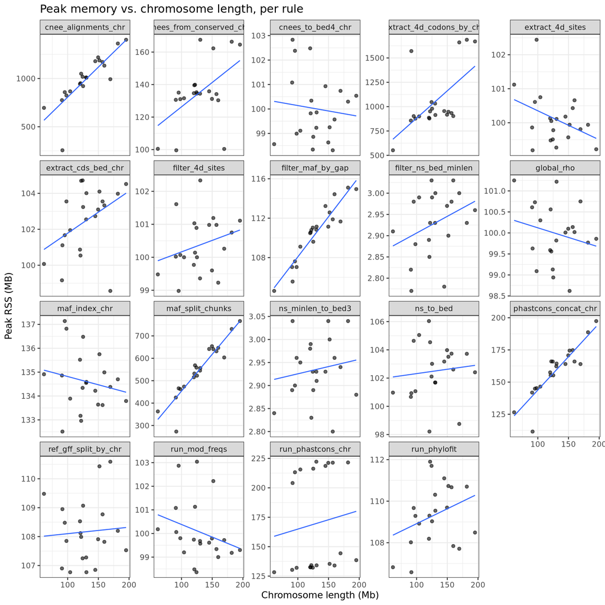

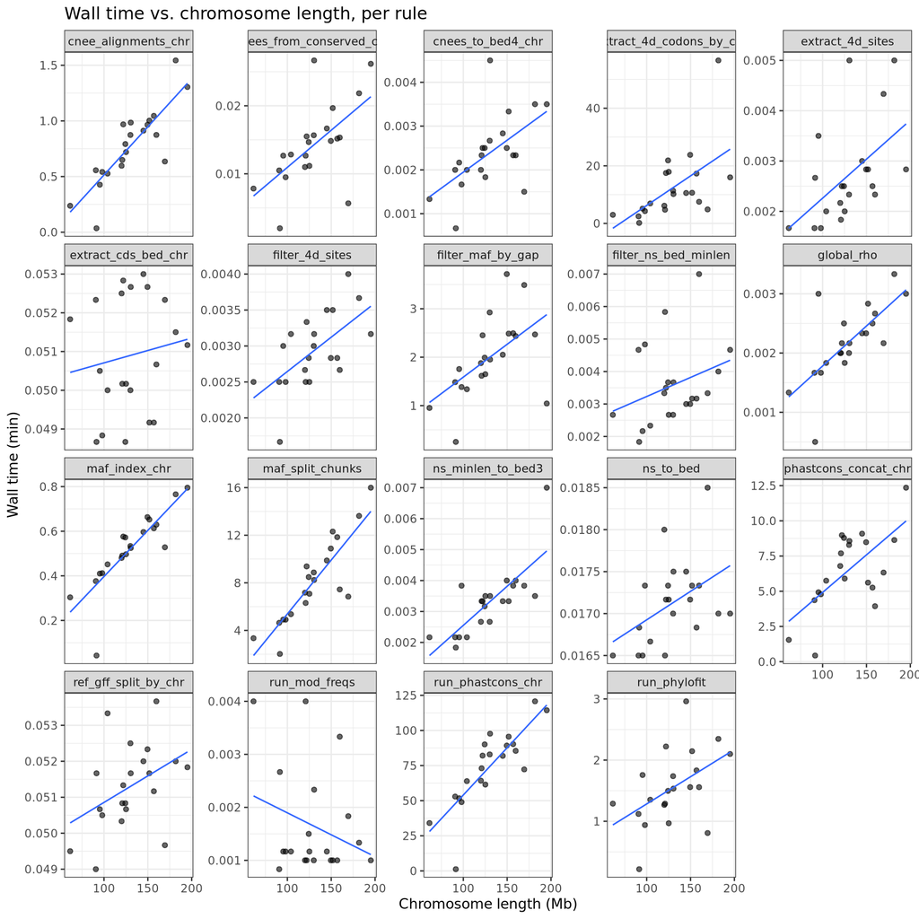

Linear fit of peak memory (MB) per Mb of chromosome length

| rule | mem_slope_mb_per_mb | mem_r2 |
| --- | --- | --- |
| cnee_alignments_chr | 6.218 | 0.693 |
| extract_4d_codons_by_chr | 5.615 | 0.357 |
| maf_split_chunks | 3.283 | 0.862 |
| phastcons_concat_chr | 0.519 | 0.805 |
| cnees_from_conserved_chr | 0.299 | 0.266 |
| run_phastcons_chr | 0.159 | 0.015 |
| filter_maf_by_gap | 0.081 | 0.881 |
| extract_cds_bed_chr | 0.023 | 0.182 |
| run_phylofit | 0.014 | 0.101 |
| filter_4d_sites | 0.007 | 0.073 |
| ns_to_bed | 0.006 | 0.011 |
| ref_gff_split_by_chr | 0.002 | 0.005 |
| filter_ns_bed_minlen | 0.001 | 0.117 |
| ns_minlen_to_bed3 | 0.000 | 0.024 |
| cnees_to_bed4_chr | -0.004 | 0.012 |
| global_rho | -0.005 | 0.046 |
| maf_index_chr | -0.007 | 0.035 |
| extract_4d_sites | -0.009 | 0.143 |
| run_mod_freqs | -0.011 | 0.075 |